# The Evolution of the Esports Industry

Mivelaz, Allan & van Kampen, Adrian

08 December, 2020

## Overview and Motivation:

The video game industry has been growing since the beginning of the millennium. From the basement of teenagers’ and geeks, it has become a wide-spread industry, with multi-million dollar games being released every year.

Similarly, so-called “E-sports” have also grown, from underground friendly tournaments to international competitions that attract millions of viewers, online and in large arenas, and pay off prizes ranging to many millions of dollars to the winner teams. As with traditional sports, this popularity is also a major business opportunity for brands that wish to get visibility to a wide audience. Starting with gaming- and electronics-related brands such as peripherals manufacturers and software developers, the virtual billboards are more and more populated by major *external* brands such as beverages, clothing and many more sectors, who begin to understand that this industry is truly booming.

In this projects, we want to give some insights about the major trends in the e-sports and gaming industry which, to the uninitiated, can seem daunting, with many different games being broadcasted, tight-knit communities having their own codes, and often unusual and innovative business models adopted by teams and individual professional players.

## Related Work:

- [TwitchTracker](https://www.twitchtracker.com) offer a few audience and user’s statistics about [Twitch.tv](https://www.twitch.tv), one of the major video-games’ streaming platform, which we wanted to recreate by our own means.
- [Kaggle](https://www.kaggle.com/) has a few nice data-sets about e-sports that use [EsportsEarnings.com](http://www.esportsearnings.com) as a source.
- [Esportsobserver.com](https://esportsobserver.com) and [McKinsey](https://www.mckinsey.com/business-functions/marketing-and-sales/our-insights/e-sports-and-the-next-frontier-of-brand-sponsorships#) also regularly publish articles about the marketing’s potential of E-sports.

Since finding data about private investments are hardly possible to get for free (even following our numerous direct inquiries to parties of interest), we are limiting our analysis to freely available data.

## Initial Questions:

- Showing the growing popularity of the platform Twitch.tv.
- Identify rising games/teams for potential marketing visibility.
- Compare the income of top companies in a period to see the potential of the industry.
- Determine the factors that influence the amount of money invested.
- Put all this information together to see the long term orientation of the industry.

## EDA for Twitch data-set

These data comes from the website : [Twitchtracker](https://twitchtracker.com/statistics)

Let’s first load the dataset :

Twitch statistics

| Date | Avg_concur_viewers | Avg_concur_channels | Hours_watched | Active_streamers | Hours_streamed | Viewers_per_streamer |
| --- | --- | --- | --- | --- | --- | --- |
| 2020-11-20 | 2490726 | 104264 | 1734.0 | NA | 72567744 | 23.9 |
| 2020-10-20 | 2385206 | 95074 | 1774.0 | 7844426 | 70719210 | 25.1 |
| 2020-09-20 | 2202200 | 91861 | 1586.0 | 7461252 | 66139920 | 24.0 |
| 2020-08-20 | 2178080 | 96309 | 1620.0 | 7709990 | 71653896 | 22.6 |
| 2020-07-20 | 2115411 | 95809 | 1574.0 | 7463817 | 71281896 | 22.1 |
| 2020-06-20 | 2262771 | 93932 | 1629.0 | 7158730 | 67631040 | 24.1 |
| 2020-05-20 | 2359765 | 100364 | 1756.0 | 7398081 | 74670816 | 23.5 |
| 2020-04-20 | 2488881 | 93750 | 1792.0 | 7213644 | 67500000 | 26.5 |
| 2020-03-20 | 1638049 | 66011 | 1219.0 | 5080031 | 49112184 | 24.8 |
| 2020-02-20 | 1410516 | 53816 | 982.0 | 3753539 | 37455936 | 26.2 |
| 2020-01-20 | 1357375 | 52821 | 1010.0 | 3935308 | 39298824 | 25.7 |
| 2019-12-20 | 1184935 | 45633 | 882.0 | 3353608 | 33950952 | 26.0 |
| 2019-11-20 | 1222247 | 45644 | 880.0 | 3198707 | 32863680 | 26.8 |
| 2019-10-20 | 1212368 | 45179 | 902.0 | 2973666 | 33613176 | 26.8 |
| 2019-09-20 | 1219579 | 46184 | 878.0 | 2942889 | 33252480 | 26.4 |
| 2019-08-20 | 1342856 | 48447 | 999.0 | 3188759 | 36044568 | 27.7 |
| 2019-07-20 | 1232595 | 48055 | 917.0 | 3355426 | 35752920 | 25.6 |
| 2019-06-20 | 1304579 | 47898 | 939.0 | 3396947 | 34486560 | 27.2 |
| 2019-05-20 | 1262560 | 48294 | 939.0 | 3933404 | 35930736 | 26.1 |
| 2019-04-20 | 1234112 | 51261 | 889.0 | 4184467 | 36907920 | 24.1 |
| 2019-03-20 | 1274016 | 54953 | 948.0 | 4389867 | 40885032 | 23.2 |
| 2019-02-20 | 1311897 | 56295 | 882.0 | 4205001 | 37830240 | 23.3 |
| 2019-01-20 | 1275970 | 55790 | 949.0 | 4537807 | 41507760 | 22.9 |
| 2018-12-20 | 1136970 | 48134 | 846.0 | 4122463 | 35811696 | 23.6 |
| 2018-11-20 | 1202989 | 45448 | 866.0 | 3743470 | 32722560 | 26.5 |
| 2018-10-20 | 1146076 | 43505 | 853.0 | 3646616 | 32367720 | 26.4 |
| 2018-09-20 | 1132031 | 44195 | 815.0 | 3670836 | 31820400 | 25.6 |
| 2018-08-20 | 1150362 | 44333 | 856.0 | 3712170 | 32983752 | 26.0 |
| 2018-07-20 | 1069217 | 41605 | 795.0 | 2957895 | 30954120 | 25.7 |
| 2018-06-20 | 1095605 | 39701 | 789.0 | 3153852 | 28584720 | 27.6 |

[output cut: 69 more lines]

We can see that these data consist of 99 observations of 7 attributes.

## Here is a description of each attribute :

- `Date` : month in which the data apply
- `Avg_concur_viewers` : Number of viewers connected in the same time in average
- `Avg_concur_channels` : Number of channels connected in the same time in average
- `Hours_watched` (in million) : Total number of hours watched per month
- `Active_streamers` : Total number of active channels
- `Hours_streamed` : Total number of hours streamed per month
- `Viewers_per_streamer` : Average number of viewers per streamer per month

## Here the graph for each variable :

##### Average concurent viewers for each month :

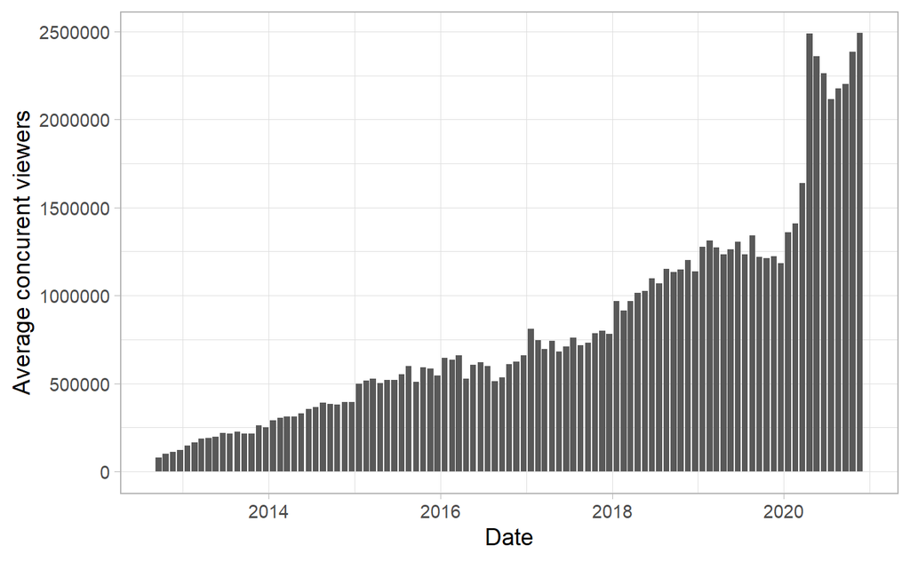

##### Average concurent channels for each month:

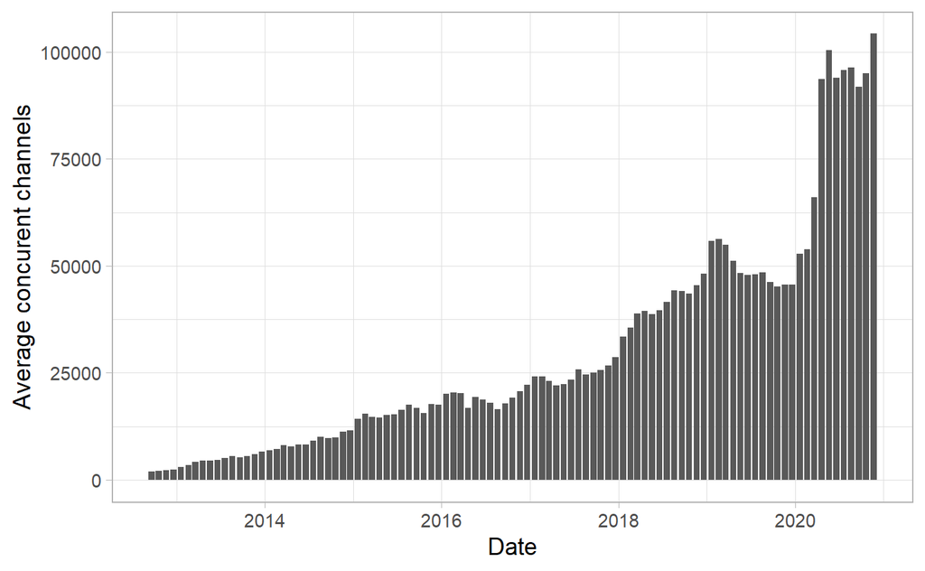

##### Total number of hours watched per month :

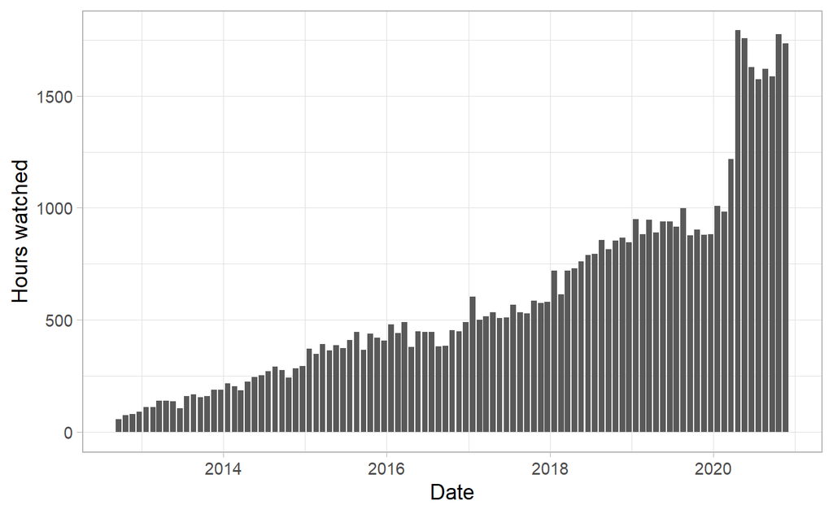

##### Total number of active channels

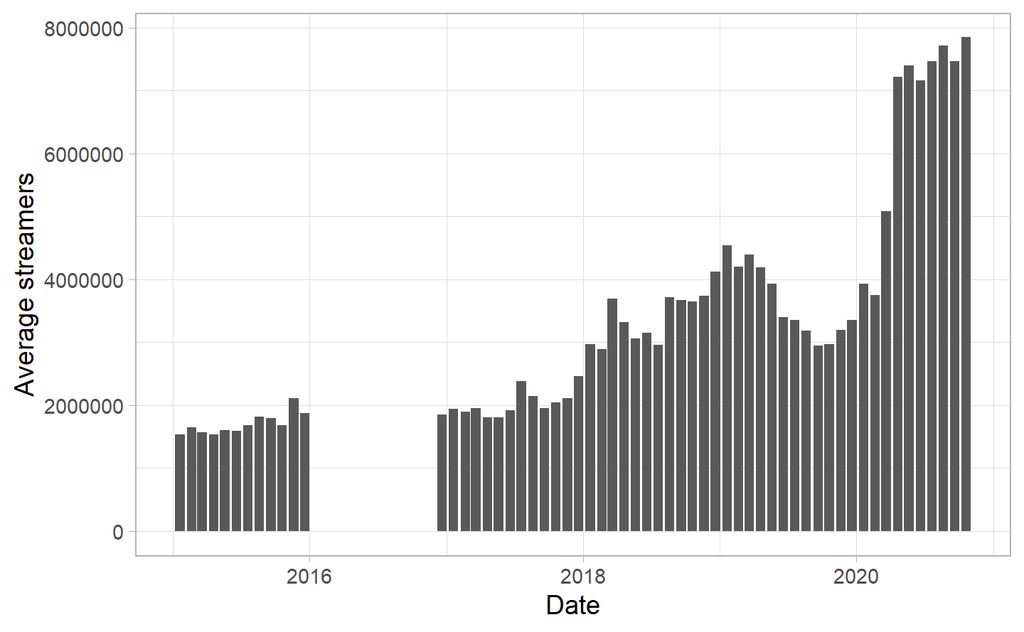

##### Total number of hours streamed per month

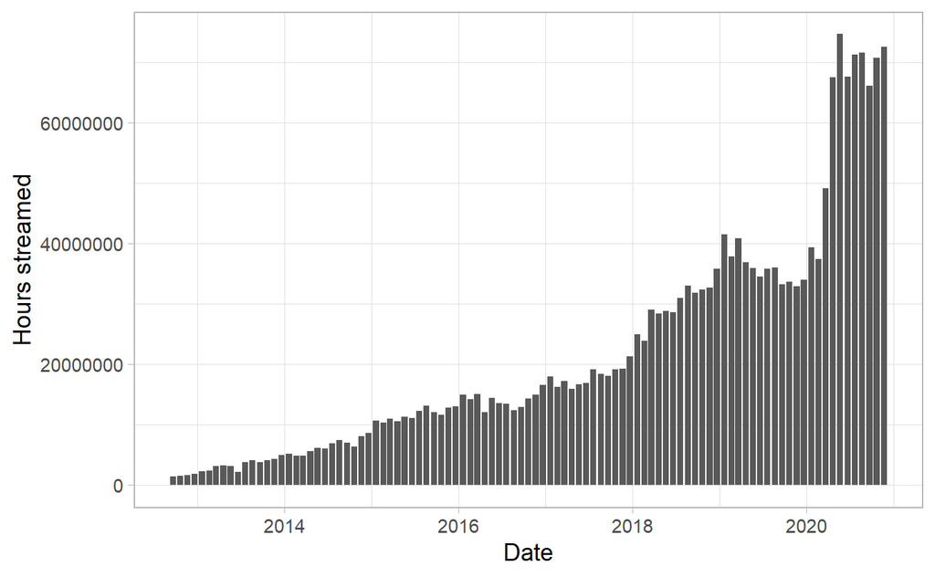

##### Average number of viewers per streamer per month

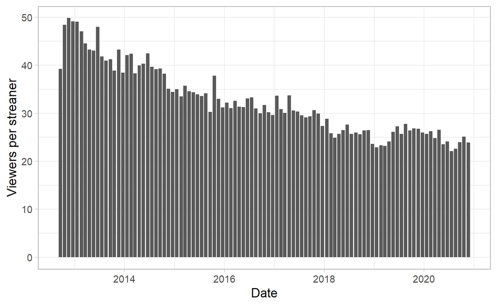

# EDA for Newzoo data-set

## These data comes from the website : [Newzoo](https://platform.newzoo.com/explorer)

Game revenu per company

| Company_name | Region_of_HQ | 2019 Q1 | 2019 Q2 | 2019 Q3 | 2019 Q4 | 2019 Full year | 2020 Q1 | 2020 YoY growth for Q1 (%) | 2020 Q2 | 2020 YoY growth for Q2 (%) | 2020 Half year |
| --- | --- | --- | --- | --- | --- | --- | --- | --- | --- | --- | --- |
| Tencent | Eastern Asia | 5020 | 4870 | 5140 | 5230 | 20260 | 6680 | 33.07 | 6730 | 38.19 | 13410 |
| Sony | Eastern Asia | 3550 | 2950 | 3140 | 3880 | 13520 | 3320 | -6.48 | 4740 | 60.68 | 8060 |
| Apple | North America | 2440 | 2660 | 2950 | 2890 | 10940 | 2560 | 4.92 | 3180 | 19.55 | 5740 |
| Microsoft | North America | 2110 | 1880 | 2270 | 2490 | 8750 | 2150 | 1.90 | 3110 | 65.43 | 5260 |
| Google | North America | 1740 | 1890 | 1950 | 1880 | 7460 | 1880 | 8.05 | 2310 | 22.22 | 4190 |
| NetEase | Eastern Asia | 1700 | 1640 | 1660 | 1670 | 6670 | 1940 | 14.12 | 1990 | 21.34 | 3930 |
| Activision Blizzard | North America | 1710 | 1280 | 1110 | 1750 | 5850 | 1660 | -2.92 | 1760 | 37.50 | 3420 |
| Nintendo | Eastern Asia | 911 | 791 | 1140 | 2290 | 5132 | 1560 | 71.24 | 1720 | 117.45 | 3280 |
| Electronic Arts | North America | 1240 | 1210 | 1350 | 1590 | 5390 | 1390 | 12.10 | 1460 | 20.66 | 2850 |
| Take-Two Interactive | North America | 539 | 540 | 858 | 930 | 2867 | 761 | 41.19 | 831 | 53.89 | 1592 |
| Bandai Namco Entertainment | Eastern Asia | 935 | 650 | 747 | 721 | 3053 | 877 | -6.20 | 711 | 9.38 | 1588 |
| Nexon | Eastern Asia | 850 | 492 | 633 | 450 | 2425 | 756 | -11.06 | 589 | 19.71 | 1345 |
| Square Enix | Eastern Asia | 557 | 339 | 440 | 470 | 1806 | 473 | -15.08 | 679 | 100.30 | 1152 |
| 37 Interactive | Eastern Asia | 443 | 429 | 501 | 526 | 1899 | 623 | 40.63 | 523 | 21.91 | 1146 |
| Netmarble | Eastern Asia | 414 | 455 | 537 | 478 | 1884 | 461 | 11.35 | 594 | 30.55 | 1055 |
| NCSoft | Eastern Asia | 261 | 311 | 306 | 424 | 1302 | 587 | 124.90 | 412 | 32.48 | 999 |
| Ubisoft | Western Europe | 758 | 352 | 388 | 510 | 2008 | 535 | -29.42 | 459 | 30.40 | 994 |
| Konami | Eastern Asia | 328 | 288 | 322 | 382 | 1320 | 408 | 24.39 | 391 | 35.76 | 799 |
| Sea Group | Southeast Asia | 173 | 229 | 329 | 404 | 1135 | 370 | 113.87 | 384 | 67.69 | 754 |
| CyberAgent | Eastern Asia | 364 | 349 | 345 | 322 | 1380 | 410 | 12.64 | 335 | -4.01 | 745 |
| Zynga | North America | 212 | 241 | 266 | 307 | 1026 | 344 | 62.26 | 388 | 61.00 | 732 |
| Century Huatong Group | Eastern Asia | 206 | 455 | 379 | 265 | 1305 | 339 | 64.56 | 379 | -16.70 | 718 |
| Warner Bros. Entertainment | North America | 399 | 552 | 497 | 565 | 2013 | 365 | -8.52 | 351 | -36.41 | 716 |
| Perfect World | Eastern Asia | 198 | 215 | 241 | 330 | 984 | 310 | 56.57 | 312 | 45.12 | 622 |
| Sega | Eastern Asia | 204 | 243 | 266 | 314 | 1027 | 322 | 57.84 | 296 | 21.81 | 618 |

`CompaniesPublicRevenues.csv` contains the revenue of the top 25 game companies for several period, where `Q1`, `Q2`, `Q3` and `Q4` correspond to every quarter of the year. For example, we can see which company generated most income in 2019.

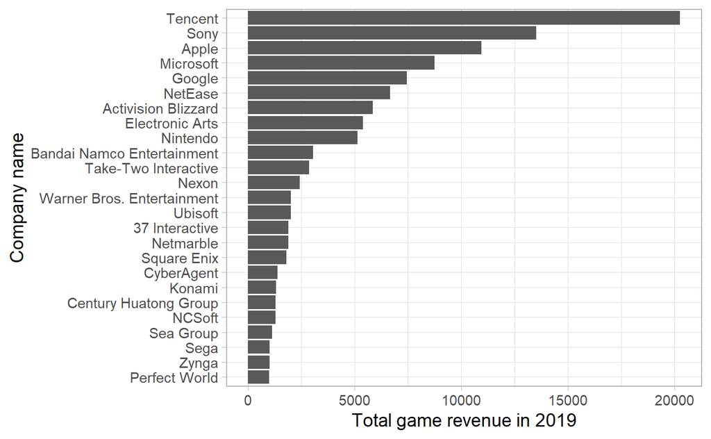

### Here an other dataset about the amount of different investment

Ammount of different investment

| Date | Investment type | Sectors | Investee | Amount |
| --- | --- | --- | --- | --- |
| 2020-11-23 | Pre seed | Social & Communication, Streaming | StreamHERO | $550K |
| 2020-11-20 | Venture | Esports | BLAST entertainment | $2.20M |
| 2020-11-17 | Seed | Agency | Queens Gaming Collective | $1.50M |
| 2020-11-16 | Seed | Mobile, Publishers & Developers | Lila Games | $2.80M |
| 2020-11-13 | Series b | Analytics, Esports, Gamestech | Statespace | $29.0M |
| 2020-11-11 | Venture | Esports | Fnatic | $10.0M |
| 2020-11-10 | Venture | Esports, Gamestech, Social & Communication | Griffin Gaming Partners | $235M |
| 2020-11-09 | Venture | Esports | Immortals Gaming Club | $26.0M |
| 2020-11-06 | Corporate | Analytics, Esports | EDGE ESPORTS | $1.50M |
| 2020-11-04 | Venture | Mobile, Gamestech | Aptoide | $1.50M |
| 2020-11-04 | Venture | Streaming | Streamloots | $7.20M |
| 2020-11-04 | Corporate | Mobile, Publishers & Developers | Lockwood Publishing | $25.0M |
| 2020-11-02 | Pre seed | Publishers & Developers | Sugar | $2.00M |
| 2020-10-29 | Acquisition | Publishers & Developers | Everguild | $1.37M |
| 2020-10-28 | Seed | Streaming, Social & Communication | Shotcall | $2.20M |
| 2020-10-28 | Series e | Publishers & Developers | Scopely | $340M |
| 2020-10-26 | Series b | Esports | VSPN | $100M |
| 2020-10-20 | Seed | Publishers & Developers | Frost Giant Studios | $4.70M |
| 2020-10-20 | Series a | Esports, Streaming | Gaming 247 (VENN) | $26.0M |
| 2020-10-16 | Series b | Esports | EVOS Esports | $12.0M |
| 2020-10-15 | Series a | Esports | Tiltify | $6.50M |
| 2020-10-14 | Corporate | Esports | Esports Mogul | $5.75M |
| 2020-10-12 | Seed | Esports | Talon Esports | $2.00M |
| 2020-10-07 | Corporate | Esports | G-Loot | $56.0M |
| 2020-10-07 | Acquisition | Publishers & Developers | East Side Games | $113M |
| 2020-09-29 | Series a | Esports, Analytics | Pandascore | $6.00M |
| 2020-09-29 | Ipo | Esports | Guild Esports | $27.5M |
| 2020-09-28 | Ipo | Hardware, Peripherals | Corsair Components | $119M |
| 2020-09-24 | Corporate | Publishers & Developers | Manticore Games | $15.0M |
| 2020-09-22 | Series c | Mobile, Esports | Mobile Premier League | $90.0M |

[output cut: 623 more lines]

`CompaniesInvestment.csv` contains the amount of several investment. It will be usefull to see if the amount is growing over the years and if depends on several factor such as the `Sectors` or the `Investment type`.

## Esports Earnings

### Data gathering

We accessed data about Esports Earnings through tournaments on the website [EsportsEarnings.com](http://www.esportsearnings.com) (which we abbreviate by “EE”).

This website provides a rather complete API to gather data in convenient `.csv` files, through multiple *methods*. Due to website limitations (and to prevent excessive traffic on their side), we are only able to get a dataset (max. 100 rows) every second at most.

Therefore, we wrote a function `build_df()` that automates the process of making API requests and builds complete datasets, 100 rows at a time, for several different methods. This function can be found in the “scripts/Functions.R” script.

Using this, we gathered several datasets:

Registered e-sports tournaments since 1996

| X1 | TournamentId | GameId | TournamentName | StartDate | EndDate | Location | Teamplay | TotalUSDPrize |
| --- | --- | --- | --- | --- | --- | --- | --- | --- |
| 1 | 44194 | 711 | Dallas Empire Battle of the Throne | 2020-11-17 | 2020-11-17 | Online | 1 | 25000 |
| 2 | 44225 | 655 | KWK Cup - Season 1 - Edition 4 | 2020-11-16 | 2020-11-16 | Online | 0 | 35 |
| 3 | 44203 | 711 | Minnesota RØKKR Launch Week Arms Race | 2020-11-16 | 2020-11-16 | Online | 1 | 25000 |
| 4 | 44213 | 152 | Afreeca Starleague Season 10 | 2020-09-06 | 2020-11-15 | Seoul, Korea | 0 | 72080 |
| 5 | 44215 | 151 | DH SC2 Masters 2020 Winter: Finals | 2020-11-10 | 2020-11-15 | Online | 0 | 57000 |

`EE_tournaments.csv` contains most registered esports tournaments across various computer games. The dataset contains 41,213 observations of 9 variables. For the not so self-explanatory variables: - **GameId** corresponds to the game being played. - **Teamplay** is 1 if the game if entities competing are teams, and 0 if the tournament is individual.

Teams’ total earnings

| X1 | TeamId | TeamName | TotalUSDPrize | TotalTournaments |
| --- | --- | --- | --- | --- |
| 1 | 102 | Team Liquid | 35732474 | 1844 |
| 2 | 419 | OG | 33943234 | 99 |
| 3 | 101 | Evil Geniuses | 24263699 | 854 |
| 4 | 118 | Fnatic | 15729228 | 929 |
| 5 | 185 | Virtus.pro | 14415574 | 510 |

`EE_teams_earnings.csv` contains most registered teams’ earnings throughout their history. It contains observations about 1,213 teams.

Prize money gained in each game.

| X1 | GameId | GameName | TotalUSDPrize | TotalTournaments | TotalPlayers |
| --- | --- | --- | --- | --- | --- |
| 1 | 711 | Call of Duty: Black Ops Cold War | 243600 | 10 | 82 |
| 2 | 655 | Trackmania (2020) | 56044 | 41 | 79 |
| 3 | 152 | StarCraft: Brood War | 8376408 | 586 | 680 |
| 4 | 151 | StarCraft II | 34243238 | 5962 | 2084 |
| 5 | 393 | Diabotical | 85282 | 45 | 205 |

`EE_games_earnings.csv` contains all the prize money won across most registered tournaments throughout each game’s history. The dataset contains observations about 480 different games.

## Initial EDA

### Ranking different games

Using the `EE_games_earnings.csv`, we displayed a few statistics to see the top games in each one (displaying only the top 5% for each statistic).

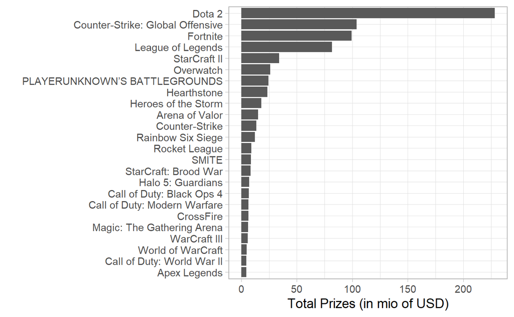

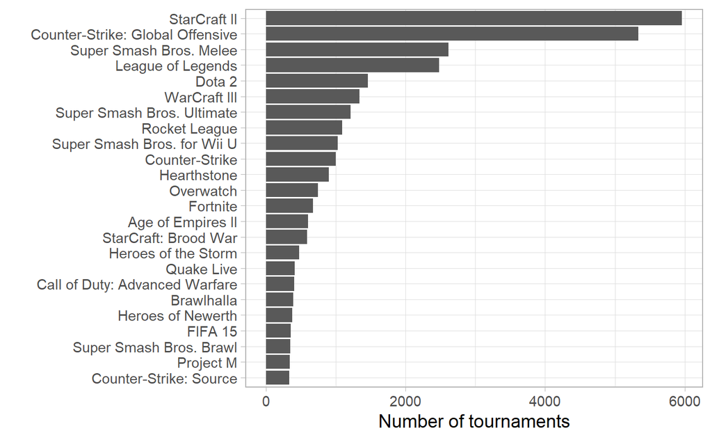

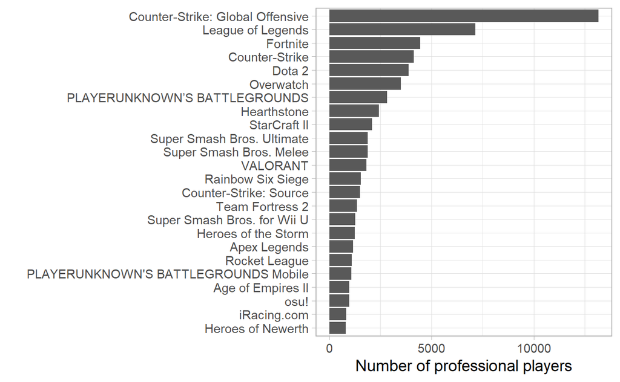

### Evolution of Esports Tournaments

We display some statistics about the evolution of esports, starting with the number of tournaments organized each month (since the first recorded tournament in 1996):

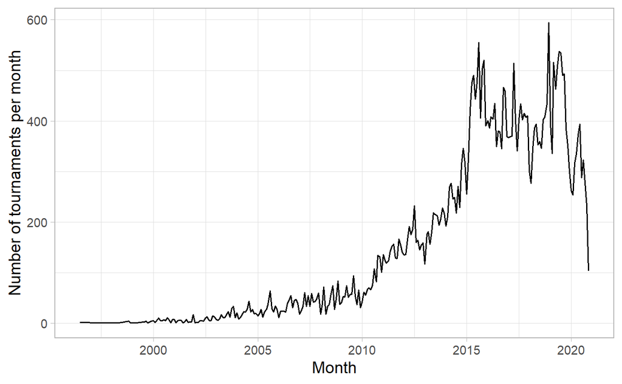

We can also display the monthly total prize money won in these tournaments:

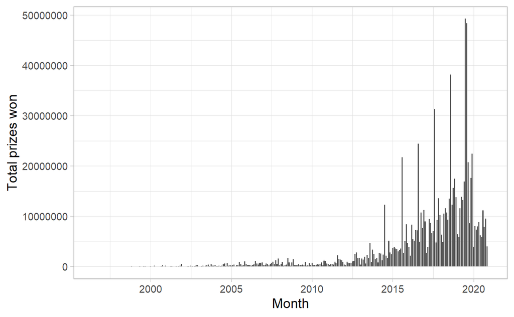

### Teams statistics

Teams with highest earnings:

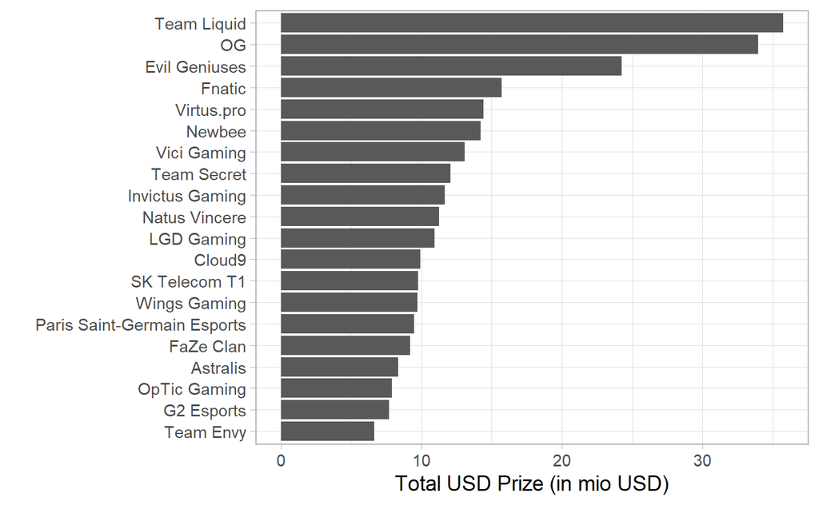

Teams with most tournaments played:

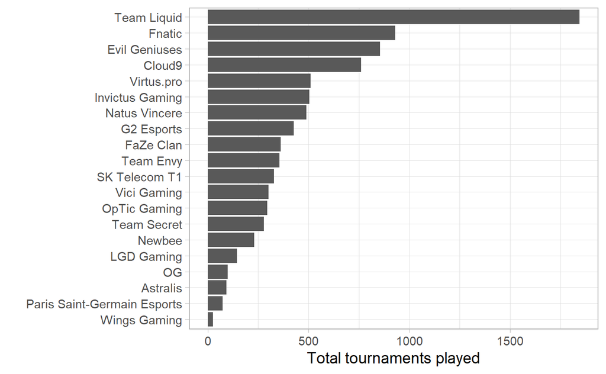

## Tournaments by game

We would like to learn a bit more about the life-cycle of games in the competitive arena. For that, let’s observe the frequency of tournaments for different games:

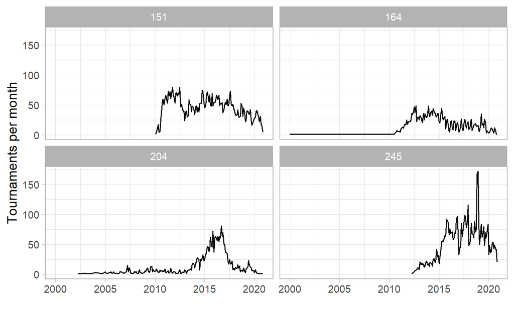